# Comcast Consumer Complaints

### 1. Importing Datatset and Packages

```python
import pandas as pd
import numpy as np
import matplotlib.pyplot as plt
comcast_consumer=pd.read_csv("Comcast Telecom Complaints data.csv")
comcast_consumer
```

|  | Ticket # | Customer Complaint | Date | Time | Received Via | City | State | Zip code | Status | Filing on Behalf of Someone |
| --- | --- | --- | --- | --- | --- | --- | --- | --- | --- | --- |
| 0 | 250635 | Comcast Cable Internet Speeds | 22-04-2015 | 3:53:50 PM | Customer Care Call | Abingdon | Maryland | 21009 | Closed | No |
| 1 | 223441 | Payment disappear - service got disconnected | 4/8/2015 | 10:22:56 AM | Internet | Acworth | Georgia | 30102 | Closed | No |
| 2 | 242732 | Speed and Service | 18-04-2015 | 9:55:47 AM | Internet | Acworth | Georgia | 30101 | Closed | Yes |
| 3 | 277946 | Comcast Imposed a New Usage Cap of 300GB that ... | 5/7/2015 | 11:59:35 AM | Internet | Acworth | Georgia | 30101 | Open | Yes |
| 4 | 307175 | Comcast not working and no service to boot | 26-05-2015 | 1:25:26 PM | Internet | Acworth | Georgia | 30101 | Solved | No |
| ... | ... | ... | ... | ... | ... | ... | ... | ... | ... | ... |
| 2219 | 213550 | Service Availability | 4/2/2015 | 9:13:18 AM | Customer Care Call | Youngstown | Florida | 32466 | Closed | No |
| 2220 | 318775 | Comcast Monthly Billing for Returned Modem | 6/2/2015 | 1:24:39 PM | Customer Care Call | Ypsilanti | Michigan | 48197 | Solved | No |
| 2221 | 331188 | complaint about comcast | 6/9/2015 | 5:28:41 PM | Internet | Ypsilanti | Michigan | 48197 | Solved | No |
| 2222 | 360489 | Extremely unsatisfied Comcast customer | 23-06-2015 | 11:13:30 PM | Customer Care Call | Ypsilanti | Michigan | 48197 | Solved | No |
| 2223 | 363614 | Comcast, Ypsilanti MI Internet Speed | 24-06-2015 | 10:28:33 PM | Customer Care Call | Ypsilanti | Michigan | 48198 | Open | Yes |

2224 rows × 10 columns

### 2. Reading column names in the dataset

```python
print(comcast_consumer.columns)
```

```
Index(['Ticket #', 'Customer Complaint', 'Date', 'Time', 'Received Via',
       'City', 'State', 'Zip code', 'Status', 'Filing on Behalf of Someone'],
      dtype='object')
```

### 3. Converting and formating the values in the 'Date' column

```python
pd.to_datetime(comcast_consumer.Date)
```

```
0      2015-04-22
1      2015-04-08
2      2015-04-18
3      2015-05-07
4      2015-05-26
          ...
2219   2015-04-02
2220   2015-06-02
2221   2015-06-09
2222   2015-06-23
2223   2015-06-24
Name: Date, Length: 2224, dtype: datetime64[ns]
```

```python
comcast_consumer.dtypes
```

```
Ticket #                       object
Customer Complaint             object
Date                           object
Time                           object
Received Via                   object
City                           object
State                          object
Zip code                        int64
Status                         object
Filing on Behalf of Someone    object
dtype: object
```

```python
comcast_consumer['Date']=pd.to_datetime(comcast_consumer.Date)
comcast_consumer
```

|  | Ticket # | Customer Complaint | Date | Time | Received Via | City | State | Zip code | Status | Filing on Behalf of Someone |
| --- | --- | --- | --- | --- | --- | --- | --- | --- | --- | --- |
| 0 | 250635 | Comcast Cable Internet Speeds | 2015-04-22 | 3:53:50 PM | Customer Care Call | Abingdon | Maryland | 21009 | Closed | No |
| 1 | 223441 | Payment disappear - service got disconnected | 2015-04-08 | 10:22:56 AM | Internet | Acworth | Georgia | 30102 | Closed | No |
| 2 | 242732 | Speed and Service | 2015-04-18 | 9:55:47 AM | Internet | Acworth | Georgia | 30101 | Closed | Yes |
| 3 | 277946 | Comcast Imposed a New Usage Cap of 300GB that ... | 2015-05-07 | 11:59:35 AM | Internet | Acworth | Georgia | 30101 | Open | Yes |
| 4 | 307175 | Comcast not working and no service to boot | 2015-05-26 | 1:25:26 PM | Internet | Acworth | Georgia | 30101 | Solved | No |
| ... | ... | ... | ... | ... | ... | ... | ... | ... | ... | ... |
| 2219 | 213550 | Service Availability | 2015-04-02 | 9:13:18 AM | Customer Care Call | Youngstown | Florida | 32466 | Closed | No |
| 2220 | 318775 | Comcast Monthly Billing for Returned Modem | 2015-06-02 | 1:24:39 PM | Customer Care Call | Ypsilanti | Michigan | 48197 | Solved | No |
| 2221 | 331188 | complaint about comcast | 2015-06-09 | 5:28:41 PM | Internet | Ypsilanti | Michigan | 48197 | Solved | No |
| 2222 | 360489 | Extremely unsatisfied Comcast customer | 2015-06-23 | 11:13:30 PM | Customer Care Call | Ypsilanti | Michigan | 48197 | Solved | No |
| 2223 | 363614 | Comcast, Ypsilanti MI Internet Speed | 2015-06-24 | 10:28:33 PM | Customer Care Call | Ypsilanti | Michigan | 48198 | Open | Yes |

2224 rows × 10 columns

```python
comcast_consumer.dtypes
```

```
Ticket #                               object
Customer Complaint                     object
Date                           datetime64[ns]
Time                                   object
Received Via                           object
City                                   object
State                                  object
Zip code                                int64
Status                                 object
Filing on Behalf of Someone            object
dtype: object
```

```python
import datetime as dt
```

```python
comcast_consumer['Date']=comcast_consumer.Date.dt.strftime('%d-%B-%y')
```

```python
comcast_consumer
```

|  | Ticket # | Customer Complaint | Date | Time | Received Via | City | State | Zip code | Status | Filing on Behalf of Someone |
| --- | --- | --- | --- | --- | --- | --- | --- | --- | --- | --- |
| 0 | 250635 | Comcast Cable Internet Speeds | 22-April-15 | 3:53:50 PM | Customer Care Call | Abingdon | Maryland | 21009 | Closed | No |
| 1 | 223441 | Payment disappear - service got disconnected | 08-April-15 | 10:22:56 AM | Internet | Acworth | Georgia | 30102 | Closed | No |
| 2 | 242732 | Speed and Service | 18-April-15 | 9:55:47 AM | Internet | Acworth | Georgia | 30101 | Closed | Yes |
| 3 | 277946 | Comcast Imposed a New Usage Cap of 300GB that ... | 07-May-15 | 11:59:35 AM | Internet | Acworth | Georgia | 30101 | Open | Yes |
| 4 | 307175 | Comcast not working and no service to boot | 26-May-15 | 1:25:26 PM | Internet | Acworth | Georgia | 30101 | Solved | No |
| ... | ... | ... | ... | ... | ... | ... | ... | ... | ... | ... |
| 2219 | 213550 | Service Availability | 02-April-15 | 9:13:18 AM | Customer Care Call | Youngstown | Florida | 32466 | Closed | No |
| 2220 | 318775 | Comcast Monthly Billing for Returned Modem | 02-June-15 | 1:24:39 PM | Customer Care Call | Ypsilanti | Michigan | 48197 | Solved | No |
| 2221 | 331188 | complaint about comcast | 09-June-15 | 5:28:41 PM | Internet | Ypsilanti | Michigan | 48197 | Solved | No |
| 2222 | 360489 | Extremely unsatisfied Comcast customer | 23-June-15 | 11:13:30 PM | Customer Care Call | Ypsilanti | Michigan | 48197 | Solved | No |
| 2223 | 363614 | Comcast, Ypsilanti MI Internet Speed | 24-June-15 | 10:28:33 PM | Customer Care Call | Ypsilanti | Michigan | 48198 | Open | Yes |

2224 rows × 10 columns

### 4. Daily complaints frequency chart

```python
Daily_freq = comcast_consumer['Date'].value_counts()
```

```python
Daily_freq
```

```
24-June-15     218
23-June-15     190
25-June-15      98
26-June-15      55
30-June-15      53
              ...
02-May-15        7
17-May-15        7
05-April-15      6
03-May-15        5
11-April-15      5
Name: Date, Length: 91, dtype: int64
```

```python
Date=Daily_freq.keys()
Date
```

```
Index(['24-June-15', '23-June-15', '25-June-15', '26-June-15', '30-June-15',
       '29-June-15', '18-June-15', '12-June-15', '27-June-15', '15-June-15',
       '13-June-15', '17-June-15', '22-June-15', '19-June-15', '05-June-15',
       '16-June-15', '08-April-15', '02-April-15', '26-May-15', '28-June-15',
       '28-May-15', '28-April-15', '27-April-15', '01-June-15', '10-June-15',
       '02-June-15', '07-April-15', '03-June-15', '13-April-15', '30-April-15',
       '08-June-15', '24-April-15', '14-April-15', '23-April-15', '09-June-15',
       '22-April-15', '29-April-15', '17-April-15', '11-June-15',
       '09-April-15', '10-April-15', '16-April-15', '20-April-15',
       '01-April-15', '27-May-15', '21-May-15', '16-May-15', '14-June-15',
       '25-April-15', '20-June-15', '08-May-15', '12-April-15', '03-April-15',
       '14-May-15', '07-May-15', '20-May-15', '06-May-15', '05-May-15',
       '22-May-15', '29-May-15', '18-May-15', '06-April-15', '04-May-15',
       '21-April-15', '04-June-15', '15-May-15', '21-June-15', '15-April-15',
       '04-April-15', '25-May-15', '13-May-15', '19-May-15', '11-May-15',
       '01-May-15', '23-May-15', '09-May-15', '06-June-15', '31-May-15',
       '07-June-15', '30-May-15', '19-April-15', '26-April-15', '18-April-15',
       '10-May-15', '12-May-15', '24-May-15', '02-May-15', '17-May-15',
       '05-April-15', '03-May-15', '11-April-15'],
      dtype='object')
```

```python
Frequency=Daily_freq.values
Frequency
```

```
array([218, 190,  98,  55,  53,  51,  47,  43,  39,  34,  32,  32,  30,
        29,  29,  29,  28,  27,  27,  27,  26,  26,  25,  25,  25,  25,
        25,  25,  24,  24,  24,  24,  23,  23,  23,  22,  22,  21,  21,
        21,  21,  20,  20,  18,  17,  17,  16,  16,  16,  16,  15,  15,
        15,  15,  15,  15,  14,  14,  14,  14,  14,  13,  12,  12,  12,
        12,  12,  12,  12,  12,  12,  12,  12,  12,  12,  11,  11,  10,
         9,   9,   9,   8,   8,   7,   7,   7,   7,   7,   6,   5,   5],
      dtype=int64)
```

```python
Daily_freq=pd.DataFrame({'Date': Date,'Frequency': Frequency})
Daily_freq
```

|  | Date | Frequency |
| --- | --- | --- |
| 0 | 24-June-15 | 218 |
| 1 | 23-June-15 | 190 |
| 2 | 25-June-15 | 98 |
| 3 | 26-June-15 | 55 |
| 4 | 30-June-15 | 53 |
| ... | ... | ... |
| 86 | 02-May-15 | 7 |
| 87 | 17-May-15 | 7 |
| 88 | 05-April-15 | 6 |
| 89 | 03-May-15 | 5 |
| 90 | 11-April-15 | 5 |

91 rows × 2 columns

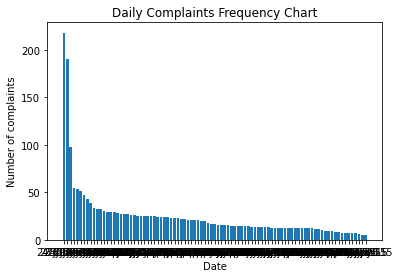

```python
plt.bar(Daily_freq['Date'], Daily_freq['Frequency'])
plt.xlabel('Date')
plt.ylabel('Number of complaints')
plt.title('Daily Complaints Frequency Chart')
plt.show()
```

Highest number of complaints received is 218 on 24th June 2015.

### 5. Monthly complaints frequency chart

```python
comcast_consumer['Date']=pd.to_datetime(comcast_consumer.Date)
comcast_consumer['Date']=comcast_consumer.Date.dt.strftime('%B')
comcast_consumer
```

|  | Ticket # | Customer Complaint | Date | Time | Received Via | City | State | Zip code | Status | Filing on Behalf of Someone |
| --- | --- | --- | --- | --- | --- | --- | --- | --- | --- | --- |
| 0 | 250635 | Comcast Cable Internet Speeds | April | 3:53:50 PM | Customer Care Call | Abingdon | Maryland | 21009 | Closed | No |
| 1 | 223441 | Payment disappear - service got disconnected | April | 10:22:56 AM | Internet | Acworth | Georgia | 30102 | Closed | No |
| 2 | 242732 | Speed and Service | April | 9:55:47 AM | Internet | Acworth | Georgia | 30101 | Closed | Yes |
| 3 | 277946 | Comcast Imposed a New Usage Cap of 300GB that ... | May | 11:59:35 AM | Internet | Acworth | Georgia | 30101 | Open | Yes |
| 4 | 307175 | Comcast not working and no service to boot | May | 1:25:26 PM | Internet | Acworth | Georgia | 30101 | Solved | No |
| ... | ... | ... | ... | ... | ... | ... | ... | ... | ... | ... |
| 2219 | 213550 | Service Availability | April | 9:13:18 AM | Customer Care Call | Youngstown | Florida | 32466 | Closed | No |
| 2220 | 318775 | Comcast Monthly Billing for Returned Modem | June | 1:24:39 PM | Customer Care Call | Ypsilanti | Michigan | 48197 | Solved | No |
| 2221 | 331188 | complaint about comcast | June | 5:28:41 PM | Internet | Ypsilanti | Michigan | 48197 | Solved | No |
| 2222 | 360489 | Extremely unsatisfied Comcast customer | June | 11:13:30 PM | Customer Care Call | Ypsilanti | Michigan | 48197 | Solved | No |
| 2223 | 363614 | Comcast, Ypsilanti MI Internet Speed | June | 10:28:33 PM | Customer Care Call | Ypsilanti | Michigan | 48198 | Open | Yes |

2224 rows × 10 columns

```python
Monthly_freq = comcast_consumer['Date'].value_counts()
Monthly_freq
```

```
June     1280
April     545
May       399
Name: Date, dtype: int64
```

```python
Month =Monthly_freq.keys()
Month
```

```
Index(['June', 'April', 'May'], dtype='object')
```

```python
Frequency= Monthly_freq.values
Frequency
```

```
array([1280,  545,  399], dtype=int64)
```

```python
Monthly_freq=pd.DataFrame({'Month': Month,'Frequency': Frequency})
Monthly_freq
```

|  | Month | Frequency |
| --- | --- | --- |
| 0 | June | 1280 |
| 1 | April | 545 |
| 2 | May | 399 |

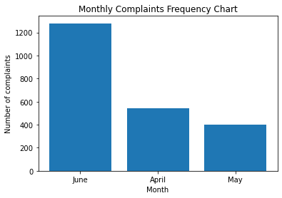

```python
plt.bar(Monthly_freq['Month'], Monthly_freq['Frequency'])
plt.xlabel('Month')
plt.ylabel('Number of complaints')
plt.title('Monthly Complaints Frequency Chart')
plt.show()
```

As we have seen in the daily frequency data chart, the number of complaints received in a day is higher for the month of June (first five instances in the daily frequency chart shows the same).  
Hence, the number of complaints received is higher for the month of June.

### 6. Type of complaint registered more number of times

```python
import nltk
import os
import nltk.corpus
import re
import string
```

```python
Freq_complaints = comcast_consumer['Customer Complaint']
Freq_complaints
```

```
0                           Comcast Cable Internet Speeds
1            Payment disappear - service got disconnected
2                                       Speed and Service
3       Comcast Imposed a New Usage Cap of 300GB that ...
4              Comcast not working and no service to boot
                              ...
2219                                 Service Availability
2220           Comcast Monthly Billing for Returned Modem
2221                              complaint about comcast
2222               Extremely unsatisfied Comcast customer
2223                 Comcast, Ypsilanti MI Internet Speed
Name: Customer Complaint, Length: 2224, dtype: object
```

```python
Freq_complaints = str(Freq_complaints)
Freq_complaints
```

```
'0                           Comcast Cable Internet Speeds\n1            Payment disappear - service got disconnected\n2                                       Speed and Service\n3       Comcast Imposed a New Usage Cap of 300GB that ...\n4              Comcast not working and no service to boot\n    …
```

```python
nltk.download('punkt')
corpus = nltk.word_tokenize(Freq_complaints)
```

```python
corpus
```

```
['0',
 'Comcast',
 'Cable',
 'Internet',
 'Speeds',
 '1',
 'Payment',
 'disappear',
 '-',
 'service',
 'got',
 'disconnected',
 '2',
 'Speed',
 'and',
 'Service',
 '3',
 'Comcast',
 'Imposed',
 'a',
 'New',
 'Usage',
 'Cap',
 'of',
 '300GB',
 'that',
 '...',
 '4',
 'Comcast',
 'not',
 'working',
 'and',
 'no',
 'service',
 'to',
 'boot',
 '...',
 '2219',
 'Service',
 'Availability',
```

[output cut: 20 more lines]

```
 'MI',
 'Internet',
 'Speed',
 'Name',
 ':',
 'Customer',
 'Complaint',
 ',',
 'Length',
 ':',
 '2224',
 ',',
 'dtype',
 ':',
 'object']
```

```python
for i in range(len(corpus )):
    corpus [i] = corpus [i].lower()
    corpus [i] = re.sub(r'\W',' ',corpus [i])
    corpus [i] = re.sub(r'\s+','',corpus [i])
```

```python
print(len(corpus))
```

```
75
```

```python
wordfreq = {}
for word in corpus:
    tokens = nltk.word_tokenize(word)
    for token in tokens:
        if token not in wordfreq.keys():
            wordfreq[token] = 1
        else:
            wordfreq[token] += 1
```

```python
print(wordfreq)
```

```
{'0': 1, 'comcast': 7, 'cable': 1, 'internet': 2, 'speeds': 1, '1': 1, 'payment': 1, 'disappear': 1, 'service': 4, 'got': 1, 'disconnected': 1, '2': 1, 'speed': 2, 'and': 2, '3': 1, 'imposed': 1, 'a': 1, 'new': 1, 'usage': 1, 'cap': 1, 'of': 1, '300gb': 1, 'that': 1, '4': 1, 'not': 1, 'working': 1, …
```

```python
import heapq
most_freq = heapq.nlargest(20, wordfreq, key=wordfreq.get)
```

```python
most_freq
```

```
['comcast',
 'service',
 'internet',
 'speed',
 'and',
 'complaint',
 'customer',
 '0',
 'cable',
 'speeds',
 '1',
 'payment',
 'disappear',
 'got',
 'disconnected',
 '2',
 '3',
 'imposed',
 'a',
 'new']
```

Since the word 'Comcast' is the name of the company and other words such as service, internet and speed are related to the complaint types, from the 'Most_freq' dataset we can derive that more number of complaints registered are regarding the service, internet and speed issue.

### 7. Replacing 'Pending' and 'Solved' values as 'Open' and 'Closed' respectively

```python
comcast_consumer['Status']=comcast_consumer['Status'].replace(['Pending','Solved'],['Open','Closed'])
comcast_consumer
```

|  | Ticket # | Customer Complaint | Date | Time | Received Via | City | State | Zip code | Status | Filing on Behalf of Someone |
| --- | --- | --- | --- | --- | --- | --- | --- | --- | --- | --- |
| 0 | 250635 | Comcast Cable Internet Speeds | April | 3:53:50 PM | Customer Care Call | Abingdon | Maryland | 21009 | Closed | No |
| 1 | 223441 | Payment disappear - service got disconnected | April | 10:22:56 AM | Internet | Acworth | Georgia | 30102 | Closed | No |
| 2 | 242732 | Speed and Service | April | 9:55:47 AM | Internet | Acworth | Georgia | 30101 | Closed | Yes |
| 3 | 277946 | Comcast Imposed a New Usage Cap of 300GB that ... | May | 11:59:35 AM | Internet | Acworth | Georgia | 30101 | Open | Yes |
| 4 | 307175 | Comcast not working and no service to boot | May | 1:25:26 PM | Internet | Acworth | Georgia | 30101 | Closed | No |
| ... | ... | ... | ... | ... | ... | ... | ... | ... | ... | ... |
| 2219 | 213550 | Service Availability | April | 9:13:18 AM | Customer Care Call | Youngstown | Florida | 32466 | Closed | No |
| 2220 | 318775 | Comcast Monthly Billing for Returned Modem | June | 1:24:39 PM | Customer Care Call | Ypsilanti | Michigan | 48197 | Closed | No |
| 2221 | 331188 | complaint about comcast | June | 5:28:41 PM | Internet | Ypsilanti | Michigan | 48197 | Closed | No |
| 2222 | 360489 | Extremely unsatisfied Comcast customer | June | 11:13:30 PM | Customer Care Call | Ypsilanti | Michigan | 48197 | Closed | No |
| 2223 | 363614 | Comcast, Ypsilanti MI Internet Speed | June | 10:28:33 PM | Customer Care Call | Ypsilanti | Michigan | 48198 | Open | Yes |

2224 rows × 10 columns

Here, to bring about the uniformity in the dataset the 'Pending' and 'Solved' values in the Status column are replaced by 'Open' and 'Closed', respectively.

### 8. Statewise complaint status stacked bar chart

```python
Open_Status = comcast_consumer.loc[(comcast_consumer.Status == "Open")]
Open_Status
```

|  | Ticket # | Customer Complaint | Date | Time | Received Via | City | State | Zip code | Status | Filing on Behalf of Someone |
| --- | --- | --- | --- | --- | --- | --- | --- | --- | --- | --- |
| 3 | 277946 | Comcast Imposed a New Usage Cap of 300GB that ... | May | 11:59:35 AM | Internet | Acworth | Georgia | 30101 | Open | Yes |
| 6 | 361148 | Throttling service and unreasonable data caps | June | 10:13:55 AM | Customer Care Call | Acworth | Georgia | 30101 | Open | No |
| 9 | 371214 | Comcast Raising Prices and Not Being Available... | June | 6:46:31 PM | Customer Care Call | Alameda | California | 94501 | Open | Yes |
| 12 | 339282 | Comcast Violating Open Internet Rules by Block... | June | 4:03:18 PM | Internet | Albuquerque | New Mexico | 87105 | Open | Yes |
| 15 | 370137 | Internet complaint | June | 3:25:03 PM | Customer Care Call | Albuquerqur | New Mexico | 87102 | Open | No |
| ... | ... | ... | ... | ... | ... | ... | ... | ... | ... | ... |
| 2196 | 339481 | Terrible internet service from Comcast | June | 7:14:02 PM | Customer Care Call | Woodbridge | Virginia | 22191 | Open | No |
| 2202 | 305166 | comcst data cap | May | 12:34:08 AM | Customer Care Call | Woodstock | Georgia | 30188 | Open | Yes |
| 2208 | 374570 | comcast cap | June | 12:42:45 PM | Customer Care Call | Woodstock | Georgia | 30188 | Open | No |
| 2218 | 338192 | Speed throttling, speeds not at promised output | June | 6:35:59 PM | Customer Care Call | Yorkville | Illinois | 60560 | Open | Yes |
| 2223 | 363614 | Comcast, Ypsilanti MI Internet Speed | June | 10:28:33 PM | Customer Care Call | Ypsilanti | Michigan | 48198 | Open | Yes |

517 rows × 10 columns

```python
K = Open_Status['State'].value_counts()
K
```

```
Georgia                 80
California              61
Tennessee               47
Florida                 39
Illinois                29
Michigan                23
Washington              23
Texas                   22
Colorado                22
Pennsylvania            20
New Jersey              19
Mississippi             16
Maryland                15
Oregon                  13
Virginia                11
Massachusetts           11
Alabama                  9
Indiana                  9
Utah                     6
Arizona                  6
Minnesota                4
New Hampshire            4
Delaware                 4
New Mexico               4
Connecticut              3
Kentucky                 3
West Virginia            3
South Carolina           3
District Of Columbia     2
Maine                    2
Louisiana                1
Vermont                  1
Kansas                   1
Missouri                 1
Name: State, dtype: int64
```

```python
State = K.keys()
State
```

```
Index(['Georgia', 'California', 'Tennessee', 'Florida', 'Illinois', 'Michigan',
       'Washington', 'Texas', 'Colorado', 'Pennsylvania', 'New Jersey',
       'Mississippi', 'Maryland', 'Oregon', 'Virginia', 'Massachusetts',
       'Alabama', 'Indiana', 'Utah', 'Arizona', 'Minnesota', 'New Hampshire',
       'Delaware', 'New Mexico', 'Connecticut', 'Kentucky', 'West Virginia',
       'South Carolina', 'District Of Columbia', 'Maine', 'Louisiana',
       'Vermont', 'Kansas', 'Missouri'],
      dtype='object')
```

```python
Open_counts = K.values
Open_counts
```

```
array([80, 61, 47, 39, 29, 23, 23, 22, 22, 20, 19, 16, 15, 13, 11, 11,  9,
        9,  6,  6,  4,  4,  4,  4,  3,  3,  3,  3,  2,  2,  1,  1,  1,  1],
      dtype=int64)
```

```python
Open = pd.DataFrame({'State': State,'Open_counts':Open_counts})
Open
```

|  | State | Open_counts |
| --- | --- | --- |
| 0 | Georgia | 80 |
| 1 | California | 61 |
| 2 | Tennessee | 47 |
| 3 | Florida | 39 |
| 4 | Illinois | 29 |
| 5 | Michigan | 23 |
| 6 | Washington | 23 |
| 7 | Texas | 22 |
| 8 | Colorado | 22 |
| 9 | Pennsylvania | 20 |
| 10 | New Jersey | 19 |
| 11 | Mississippi | 16 |
| 12 | Maryland | 15 |
| 13 | Oregon | 13 |
| 14 | Virginia | 11 |
| 15 | Massachusetts | 11 |
| 16 | Alabama | 9 |
| 17 | Indiana | 9 |
| 18 | Utah | 6 |
| 19 | Arizona | 6 |
| 20 | Minnesota | 4 |
| 21 | New Hampshire | 4 |
| 22 | Delaware | 4 |
| 23 | New Mexico | 4 |
| 24 | Connecticut | 3 |
| 25 | Kentucky | 3 |
| 26 | West Virginia | 3 |
| 27 | South Carolina | 3 |
| 28 | District Of Columbia | 2 |
| 29 | Maine | 2 |
| 30 | Louisiana | 1 |
| 31 | Vermont | 1 |
| 32 | Kansas | 1 |
| 33 | Missouri | 1 |

In the above chart it is seen that the State of 'Georgia' has the higher number of 'Open' complaints that is 80.

```python
Open.columns
```

```
Index(['State', 'Open_counts'], dtype='object')
```

```python
Closed_Status = comcast_consumer.loc[(comcast_consumer.Status == "Closed")]
Closed_Status
```

|  | Ticket # | Customer Complaint | Date | Time | Received Via | City | State | Zip code | Status | Filing on Behalf of Someone |
| --- | --- | --- | --- | --- | --- | --- | --- | --- | --- | --- |
| 0 | 250635 | Comcast Cable Internet Speeds | April | 3:53:50 PM | Customer Care Call | Abingdon | Maryland | 21009 | Closed | No |
| 1 | 223441 | Payment disappear - service got disconnected | April | 10:22:56 AM | Internet | Acworth | Georgia | 30102 | Closed | No |
| 2 | 242732 | Speed and Service | April | 9:55:47 AM | Internet | Acworth | Georgia | 30101 | Closed | Yes |
| 4 | 307175 | Comcast not working and no service to boot | May | 1:25:26 PM | Internet | Acworth | Georgia | 30101 | Closed | No |
| 5 | 338519 | ISP Charging for arbitrary data limits with ov... | June | 9:59:40 PM | Internet | Acworth | Georgia | 30101 | Closed | No |
| ... | ... | ... | ... | ... | ... | ... | ... | ... | ... | ... |
| 2217 | 254488 | problems with internet service | April | 5:05:25 AM | Internet | York Haven | Pennsylvania | 17370 | Closed | No |
| 2219 | 213550 | Service Availability | April | 9:13:18 AM | Customer Care Call | Youngstown | Florida | 32466 | Closed | No |
| 2220 | 318775 | Comcast Monthly Billing for Returned Modem | June | 1:24:39 PM | Customer Care Call | Ypsilanti | Michigan | 48197 | Closed | No |
| 2221 | 331188 | complaint about comcast | June | 5:28:41 PM | Internet | Ypsilanti | Michigan | 48197 | Closed | No |
| 2222 | 360489 | Extremely unsatisfied Comcast customer | June | 11:13:30 PM | Customer Care Call | Ypsilanti | Michigan | 48197 | Closed | No |

1707 rows × 10 columns

```python
P = Closed_Status['State'].value_counts()
P
```

```
Georgia                 208
Florida                 201
California              159
Illinois                135
Pennsylvania            110
Tennessee                96
Michigan                 92
Washington               75
Maryland                 63
Colorado                 58
New Jersey               56
Indiana                  50
Massachusetts            50
Virginia                 49
Texas                    49
Oregon                   36
Minnesota                29
Mississippi              23
Alabama                  17
Utah                     16
South Carolina           15
District Of Columbia     14
Arizona                  14
Louisiana                12
New Mexico               11
Connecticut               9
West Virginia             8
New Hampshire             8
Delaware                  8
Arkansas                  6
New York                  6
Kentucky                  4
Missouri                  3
Ohio                      3
Maine                     3
North Carolina            3
Vermont                   2
District of Columbia      1
Montana                   1
Iowa                      1
Rhode Island              1
Kansas                    1
Nevada                    1
Name: State, dtype: int64
```

```python
State = P.keys()
State
```

```
Index(['Georgia', 'Florida', 'California', 'Illinois', 'Pennsylvania',
       'Tennessee', 'Michigan', 'Washington', 'Maryland', 'Colorado',
       'New Jersey', 'Indiana', 'Massachusetts', 'Virginia', 'Texas', 'Oregon',
       'Minnesota', 'Mississippi', 'Alabama', 'Utah', 'South Carolina',
       'District Of Columbia', 'Arizona', 'Louisiana', 'New Mexico',
       'Connecticut', 'West Virginia', 'New Hampshire', 'Delaware', 'Arkansas',
       'New York', 'Kentucky', 'Missouri', 'Ohio', 'Maine', 'North Carolina',
       'Vermont', 'District of Columbia', 'Montana', 'Iowa', 'Rhode Island',
       'Kansas', 'Nevada'],
      dtype='object')
```

```python
Closed_counts = P.values
Closed_counts
```

```
array([208, 201, 159, 135, 110,  96,  92,  75,  63,  58,  56,  50,  50,
        49,  49,  36,  29,  23,  17,  16,  15,  14,  14,  12,  11,   9,
         8,   8,   8,   6,   6,   4,   3,   3,   3,   3,   2,   1,   1,
         1,   1,   1,   1], dtype=int64)
```

```python
Closed = pd.DataFrame({'State': State,'Closed_counts':Closed_counts})
Closed
```

|  | State | Closed_counts |
| --- | --- | --- |
| 0 | Georgia | 208 |
| 1 | Florida | 201 |
| 2 | California | 159 |
| 3 | Illinois | 135 |
| 4 | Pennsylvania | 110 |
| 5 | Tennessee | 96 |
| 6 | Michigan | 92 |
| 7 | Washington | 75 |
| 8 | Maryland | 63 |
| 9 | Colorado | 58 |
| 10 | New Jersey | 56 |
| 11 | Indiana | 50 |
| 12 | Massachusetts | 50 |
| 13 | Virginia | 49 |
| 14 | Texas | 49 |
| 15 | Oregon | 36 |
| 16 | Minnesota | 29 |
| 17 | Mississippi | 23 |
| 18 | Alabama | 17 |
| 19 | Utah | 16 |
| 20 | South Carolina | 15 |
| 21 | District Of Columbia | 14 |
| 22 | Arizona | 14 |
| 23 | Louisiana | 12 |
| 24 | New Mexico | 11 |
| 25 | Connecticut | 9 |
| 26 | West Virginia | 8 |
| 27 | New Hampshire | 8 |
| 28 | Delaware | 8 |
| 29 | Arkansas | 6 |
| 30 | New York | 6 |
| 31 | Kentucky | 4 |
| 32 | Missouri | 3 |
| 33 | Ohio | 3 |
| 34 | Maine | 3 |
| 35 | North Carolina | 3 |
| 36 | Vermont | 2 |
| 37 | District of Columbia | 1 |
| 38 | Montana | 1 |
| 39 | Iowa | 1 |
| 40 | Rhode Island | 1 |
| 41 | Kansas | 1 |
| 42 | Nevada | 1 |

In the above chart it is seen that the state of 'Georgia' has highest number of closed complaints that is 208.

```python
Statewise_status = Closed.merge(Open,how='left')
```

```python
Statewise_status
```

|  | State | Closed_counts | Open_counts |
| --- | --- | --- | --- |
| 0 | Georgia | 208 | 80.0 |
| 1 | Florida | 201 | 39.0 |
| 2 | California | 159 | 61.0 |
| 3 | Illinois | 135 | 29.0 |
| 4 | Pennsylvania | 110 | 20.0 |
| 5 | Tennessee | 96 | 47.0 |
| 6 | Michigan | 92 | 23.0 |
| 7 | Washington | 75 | 23.0 |
| 8 | Maryland | 63 | 15.0 |
| 9 | Colorado | 58 | 22.0 |
| 10 | New Jersey | 56 | 19.0 |
| 11 | Indiana | 50 | 9.0 |
| 12 | Massachusetts | 50 | 11.0 |
| 13 | Virginia | 49 | 11.0 |
| 14 | Texas | 49 | 22.0 |
| 15 | Oregon | 36 | 13.0 |
| 16 | Minnesota | 29 | 4.0 |
| 17 | Mississippi | 23 | 16.0 |
| 18 | Alabama | 17 | 9.0 |
| 19 | Utah | 16 | 6.0 |
| 20 | South Carolina | 15 | 3.0 |
| 21 | District Of Columbia | 14 | 2.0 |
| 22 | Arizona | 14 | 6.0 |
| 23 | Louisiana | 12 | 1.0 |
| 24 | New Mexico | 11 | 4.0 |
| 25 | Connecticut | 9 | 3.0 |
| 26 | West Virginia | 8 | 3.0 |
| 27 | New Hampshire | 8 | 4.0 |
| 28 | Delaware | 8 | 4.0 |
| 29 | Arkansas | 6 | NaN |
| 30 | New York | 6 | NaN |
| 31 | Kentucky | 4 | 3.0 |
| 32 | Missouri | 3 | 1.0 |
| 33 | Ohio | 3 | NaN |
| 34 | Maine | 3 | 2.0 |
| 35 | North Carolina | 3 | NaN |
| 36 | Vermont | 2 | 1.0 |
| 37 | District of Columbia | 1 | NaN |
| 38 | Montana | 1 | NaN |
| 39 | Iowa | 1 | NaN |
| 40 | Rhode Island | 1 | NaN |
| 41 | Kansas | 1 | 1.0 |
| 42 | Nevada | 1 | NaN |

Two datasets, 'Open_counts' and 'Closed_counts' are merged to form a new dataset named 'Statewise_status'.

```python
Statewise_status.dtypes
```

```
State             object
Closed_counts      int64
Open_counts      float64
dtype: object
```

```python
Statewise_status["Open_counts"] = Statewise_status["Open_counts"].fillna(0)
print(Statewise_status)
```

```
                   State  Closed_counts  Open_counts
0                Georgia            208         80.0
1                Florida            201         39.0
2             California            159         61.0
3               Illinois            135         29.0
4           Pennsylvania            110         20.0
5              Tennessee             96         47.0
6               Michigan             92         23.0
7             Washington             75         23.0
8               Maryland             63         15.0
9               Colorado             58         22.0
10            New Jersey             56         19.0
11               Indiana             50          9.0
12         Massachusetts             50         11.0
13              Virginia             49         11.0
```

[output cut: 29 more lines]

Above, the NaN values are replaced with 0.

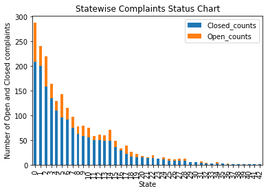

```python
Statewise_status.plot(kind='bar', stacked = True)
plt.xlabel('State')
plt.ylabel('Number of Open and Closed complaints')
plt.title('Statewise Complaints Status Chart')
plt.show()
```

Above stacked bar chart shows the number of closed and open complaints for all the states. The state of 'Georgia' has the highest number of open and closed complaints as the total complaints are also high for this state.

### 9. State with maximum number of complaints

```python
Maximum_complaints = comcast_consumer['State'].value_counts()
max(Maximum_complaints)
```

```
288
```

```python
Maximum_complaints
```

```
Georgia                 288
Florida                 240
California              220
Illinois                164
Tennessee               143
Pennsylvania            130
Michigan                115
Washington               98
Colorado                 80
Maryland                 78
New Jersey               75
Texas                    71
Massachusetts            61
Virginia                 60
Indiana                  59
Oregon                   49
Mississippi              39
Minnesota                33
Alabama                  26
Utah                     22
Arizona                  20
South Carolina           18
District Of Columbia     16
New Mexico               15
Louisiana                13
New Hampshire            12
Delaware                 12
Connecticut              12
West Virginia            11
Kentucky                  7
New York                  6
Arkansas                  6
Maine                     5
Missouri                  4
Ohio                      3
Vermont                   3
North Carolina            3
Kansas                    2
Rhode Island              1
Nevada                    1
District of Columbia      1
Iowa                      1
Montana                   1
Name: State, dtype: int64
```

With 288 complaints the state of 'Georgia' has highest number of complaints, followed by the 'Florida' and 'California' with 240 and 220 complaints, respectively.

### 10. State with highest percentage of unresolved complaints

```python
Open['Percentage_of_Unresolved_complaints']= Open['Open_counts']/sum(Open_counts)*100
```

```python
Open
```

|  | State | Open_counts | Percentage_of_Unresolved_complaints |
| --- | --- | --- | --- |
| 0 | Georgia | 80 | 15.473888 |
| 1 | California | 61 | 11.798839 |
| 2 | Tennessee | 47 | 9.090909 |
| 3 | Florida | 39 | 7.543520 |
| 4 | Illinois | 29 | 5.609284 |
| 5 | Washington | 23 | 4.448743 |
| 6 | Michigan | 23 | 4.448743 |
| 7 | Texas | 22 | 4.255319 |
| 8 | Colorado | 22 | 4.255319 |
| 9 | Pennsylvania | 20 | 3.868472 |
| 10 | New Jersey | 19 | 3.675048 |
| 11 | Mississippi | 16 | 3.094778 |
| 12 | Maryland | 15 | 2.901354 |
| 13 | Oregon | 13 | 2.514507 |
| 14 | Massachusetts | 11 | 2.127660 |
| 15 | Virginia | 11 | 2.127660 |
| 16 | Alabama | 9 | 1.740812 |
| 17 | Indiana | 9 | 1.740812 |
| 18 | Utah | 6 | 1.160542 |
| 19 | Arizona | 6 | 1.160542 |
| 20 | New Hampshire | 4 | 0.773694 |
| 21 | Minnesota | 4 | 0.773694 |
| 22 | Delaware | 4 | 0.773694 |
| 23 | New Mexico | 4 | 0.773694 |
| 24 | Kentucky | 3 | 0.580271 |
| 25 | Connecticut | 3 | 0.580271 |
| 26 | South Carolina | 3 | 0.580271 |
| 27 | West Virginia | 3 | 0.580271 |
| 28 | Maine | 2 | 0.386847 |
| 29 | District Of Columbia | 2 | 0.386847 |
| 30 | Missouri | 1 | 0.193424 |
| 31 | Vermont | 1 | 0.193424 |
| 32 | Kansas | 1 | 0.193424 |
| 33 | Louisiana | 1 | 0.193424 |

```python
Open['Percentage_of_Unresolved_complaints'].max()
```

```
15.473887814313347
```

The above calculation shows the percentage of open complaints for the states with respect to the total number of open complaints. The percentage of the open complaints is high for the state of 'Georgia' with 15.47%.

### 11. Percentage of the total resolved complaints received via 'Internet' and 'Customer Care Call'

```python
comcast_consumer.columns
```

```
Index(['Ticket #', 'Customer Complaint', 'Date', 'Time', 'Received Via',
       'City', 'State', 'Zip code', 'Status', 'Filing on Behalf of Someone'],
      dtype='object')
```

```python
comcast_consumer['Received Via'].value_counts()
```

```
Customer Care Call    1119
Internet              1105
Name: Received Via, dtype: int64
```

As required,the entire datset comprise of the complaints received via internet and customer care call, hence taking the data as it is.

```python
Total_complaints  = comcast_consumer['Status'].value_counts()
Total_complaints
```

```
Closed    1707
Open       517
Name: Status, dtype: int64
```

```python
Total_complaints = sum(Total_complaints )
Total_complaints
```

```
2224
```

The total number of complaints received by all the states is 2224.

```python
Total_Resolved_complaints = sum(Closed['Closed_counts'])
Total_Resolved_complaints
```

```
1707
```

The total number of complaints resolved by all the states is 1707.

```python
Percentage_of_resolved_complaints =Total_Resolved_complaints/Total_complaints*100
Percentage_of_resolved_complaints
```

```
76.75359712230215
```

The percentage of complaints resolved is 76.75%.